# Cyclistic: analisis de uso (Q1 2019-2020)

Maximiliano Zanardi

2025-10-26

## **Introducción**

**Objetivo**:identificar diferencias de uso entre usuarios casuales y miembros anuales para proponer acciones utilizables a una futura campaña y estrategia de marketing para poder convertir a los usuarios casuales en usuarios anuales.

**Pregunta guía**: ¿en qué difieren los patrones de uso (duración, frecuencia, días) entre ambos grupos?

## **Datos y limpieza (resumen)**

Para este proyecto voy a utilizar los conjuntos de datos Divvy 2019 Q1 y Divvy 2020 Q1. Estos datos son provistos por [Motivate International Inc.(Divvy Data)](https://divvy-tripdata.s3.amazonaws.com/index.html) bajo licencia abierta y no contienen información personal identificable, lo que garantiza su uso ético y seguro con fines educativos.

- Datos originales: Divvy_Trips_2019_Q1.csv y Divvy_Trips_2020_Q1.csv.
- Unificación en all_trips_q1.
- Variables creadas:
  - ride_length (minutos) = end_time - start_time
  - day_of_week (nombre del día)
  - member_casual (mapa de usertype → casual/member)
- Filtro de calidad: se removieron viajes < 1 min y > 24 hs.
- Dataset limpio guardado como Data/all_trips_q1_clean.csv.

**Nota**: Esta sección es descriptiva; el detalle del código está disponible en el script del proyecto.

## **Análisis descriptivo**

#### Resumen por tipo de usuario

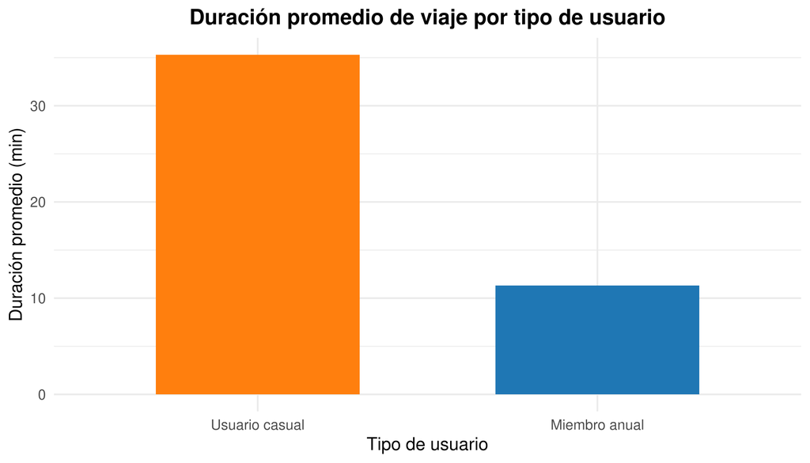

**lectura:** Como se puede observar los usuarios casuales realizan viajes más largos (35min) que los miembros anuales (11min). Esto da por entendido o sugiere que los usuarios casuales utilizan las bicicletas con fines más recreativos, como paseos o viajes turísticos, mientras que los demás son para casos puntuales, por ejemplo podría ser para ir a trabajar.

##### Duración promedio por día de la semana

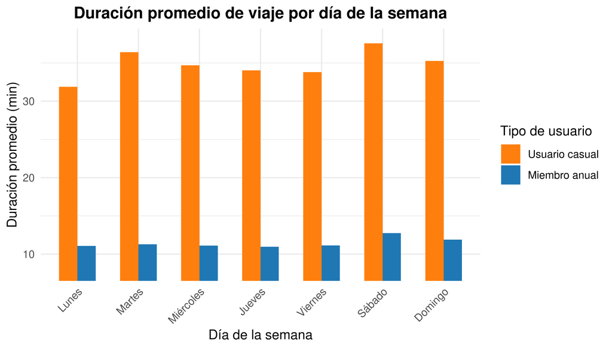

**Lectura:** Se puede observar cómo los usuarios casuales tienen un mayor uso en promedio los días sábado, que serían los fines de semana. Mientras que los usuarios anuales lo usan de una manera más pareja todos los días de la semana en promedio.

#### Cantidad de viajes por día de la semana

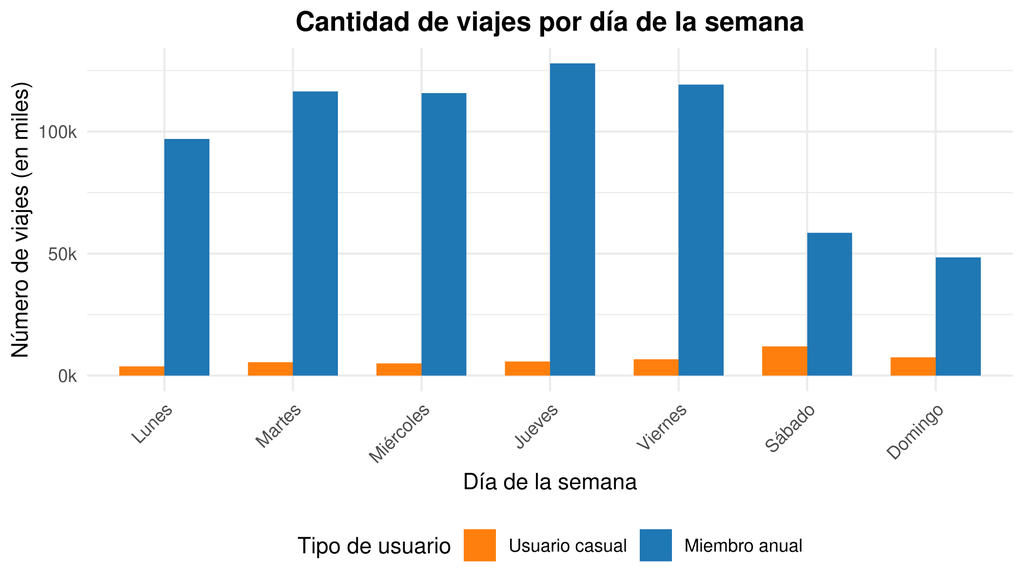

**Lectura:** Los usuarios anuales utilizan las bicicletas con una diferencia notable en cantidad de viajes que los usuarios casuales, y esto se da más que nada de lunes a viernes. Con esto me permito decir que hacen un uso más funcional y habitual del servicio.

Como conclusión, podría decir que se muestra dos diferentes tipos de usuarios bien marcados. Están los usuarios casuales que utilizan el servicio para experiencias más turísticas y esporádicas con viajes más largos. Y luego tenemos a los usuarios anuales con viajes más cortos pero más habituales y funcionales para casos más concretos y recurrentes.

Con estos hallazgos se puede lograr convertir a los usuarios casuales en anuales a través de campañas de marketing bien orientadas, como por ejemplo beneficios exclusivos o promociones los fines de semana que es donde se hacen más presentes este tipo de usuarios casuales.

Para terminar me gustaría agregar otra visualización gráfica que puede ser de gran ayuda.

#### Top 10 estaciones más populares

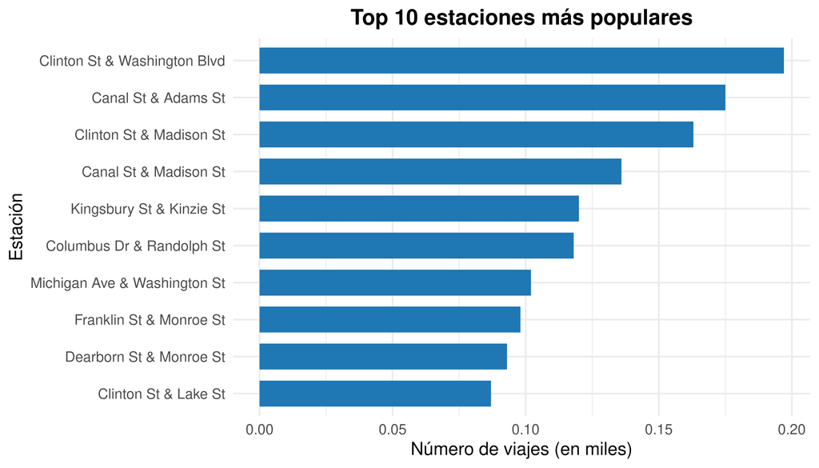

**Lectura:** Este gráfico muestra las 10 estaciones más utilizadas que son los puntos de mayor concentración de toda la red. Las estaciones con mayor movimiento corresponden a zonas céntricas y/o turísticas, lo que explica que ahí es donde se producen la mayor cantidad de viajes tanto de los usuarios anuales con sus viajes habituales y los esporádicos de los usuarios casuales. **Nota:** El gráfico se presenta en formato horizontal para facilitar la lectura de los nombres de las estaciones. Los valores del eje representan el número de viajes expresado en miles (k).

Con esta última visualización que me atreví a poner a su disposición puedo agregar que las campañas de marketing, que surgirán posteriormente, tendrían que estar enfocadas en estas estaciones y/o zonas aledañas ya que ahí está el mayor foco de concentración de ambos tipos de usuarios.

## **Conclusiones y recomendaciones**

A partir de los análisis y visualizaciones realizadas se identificaron patrones de comportamiento muy claros entre los dos tipos de usuarios de Cyclistic.

- 1- Usuarios casuales: utilizan el servicio para viajes más largos y principalmente los fines de semana, lo que sugiere un uso más recreativo y esporádico.
- 2- Usuarios anuales: utilizan el servicio con más habitualidad y de forma más funcional, además hacen viajes más cortos y con mayor frecuencia los días de semana. Esto probablemente esté ligado a viajes para ir a trabajar o actividades puntuales y cotidianas.
- 3- Zonas más concurridas: las estaciones más utilizadas están en zonas céntricas y turísticas. Esto sugiere que aquí debería estar puesto el foco para hacer campañas de marketing y convertir clientes casuales en anuales utilizando estrategias óptimas y claves.

#### **Recomendaciones principales:**

- Campañas de conversión: ofrecer algún tipo de descuento o beneficio especiales los fines de semana como incentivo de convertir a los usuario causales en anuales.
- Optimización de recursos: reforzar la disponibilidad de bicicletas y mantenimiento de las mismas en las zonas céntricas y turísticas donde está el mayor foco de actividad.
- Análisis complementario: profundizar en variables como hora del día, tipo de bicicleta y condiciones climáticas para mejorar la precisión de futuras campañas.

Con estas recomendaciones Cyclistic puede aumentar el número de usuarios anuales, mejorar la experiencia de usuario y optimizar su red de ubicación y distribución de bicicletas.